# RQ2.2 Political Information Seeking Models

How do feelings about the future affect young people’s political information seeking?

```r
load(here(data_dir, "analysis", "df_wide.RData"))
df <- df_wide
rm(df_wide)
```

### Quick Look at Data

```r
df |>
  mutate(
    exp_polinfo = factor(exp_polinfo,
                         levels = c("No, I do not want to see information on how to get more involved in democracy",
                                    "Yes, I want to see information on how to get more involved in democracy"),
                         labels = c("No", "Yes"))) |>
  datasummary_crosstab(exp_polinfo ~ exp_condition, data = _)
```

| exp_polinfo |  | control | hope | anxiety | All |
| --- | --- | --- | --- | --- | --- |
| No | N | 403 | 359 | 395 | 1157 |
|  | % row | 34.8 | 31.0 | 34.1 | 100.0 |
| Yes | N | 228 | 272 | 238 | 738 |
|  | % row | 30.9 | 36.9 | 32.2 | 100.0 |
| All | N | 631 | 631 | 633 | 1895 |
|  | % row | 33.3 | 33.3 | 33.4 | 100.0 |

Unique

Missing Pct.

Mean

SD

Min

Median

Max

Histogram

exp_polinfo_time

734

61

18.2

52.4

1.7

7.7

1271.4

[figure not shown]

exp_polinfo

N

%

No

1157

61.1

Yes

738

38.9

```r
df |>
  mutate(
    exp_polinfo = factor(exp_polinfo,
                         levels = c("No, I do not want to see information on how to get more involved in democracy",
                                    "Yes, I want to see information on how to get more involved in democracy"),
                         labels = c("No", "Yes"))) |>
  select(exp_polinfo, exp_polinfo_time) |>
  datasummary_skim()
```

```r
df |>
  filter(exp_polinfo == "Yes, I want to see information on how to get more involved in democracy") |>
  datasummary(exp_polinfo_time ~ exp_condition * (Mean + Median + SD),
              data = _,
              fmt = 2)
```

|  | control Mean | control Median | control SD | hope Mean | hope Median | hope SD | anxiety Mean | anxiety Median | anxiety SD |
| --- | --- | --- | --- | --- | --- | --- | --- | --- | --- |
| exp_polinfo_time | 14.28 | 8.23 | 17.68 | 18.03 | 7.19 | 31.43 | 22.16 | 8.07 | 84.22 |

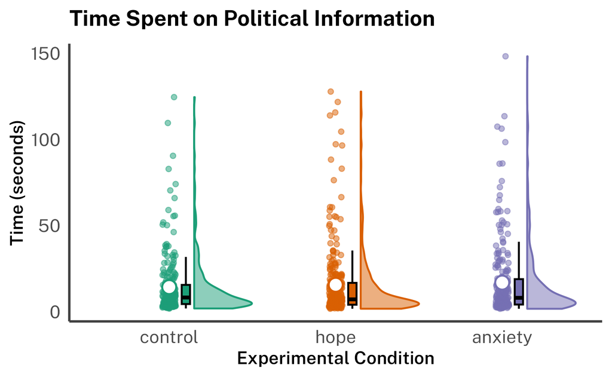

```r
df |>
  filter(exp_polinfo == "Yes, I want to see information on how to get more involved in democracy") |>
  filter(exp_polinfo_time < 150) |>
  ggplot(aes(x = exp_condition, y = exp_polinfo_time,
             fill = exp_condition, color = exp_condition)) +
  geom_rain(
    alpha = 0.5,
    boxplot.args = list(color = "black", outlier.shape = NA)
  ) +
  stat_summary(
    fun = mean,
    geom = "point",
    size = 4,
    fill = "white",
    shape = 21,
    stroke = 1
  ) +
  scale_fill_brewer(palette = "Dark2") +
  scale_color_brewer(palette = "Dark2") +
  labs(
    title = "Time Spent on Political Information",
    x = "Experimental Condition",
    y = "Time (seconds)"
  ) +
  theme(
    legend.position = "none"
  )
```

### Main Models to Estimate the ATEs

```r
# Model data
df_info <- df |>
  mutate(
    polinfo_choice = case_when(
      exp_polinfo == "No, I do not want to see information on how to get more involved in democracy" ~ 0,
      exp_polinfo == "Yes, I want to see information on how to get more involved in democracy" ~ 1,
      TRUE ~ NA_integer_),
    polinfo_time = exp_polinfo_time
  ) |>
  mutate(
    polinfo = if_else(polinfo_choice == 1, polinfo_time, 0)
  )
```

```r
# brms settings
bayes_seed <- 42
chains <- 4
iter <- 4000
warmup <- floor(iter/2)
adapt_delta <- 0.90
max_treedepth <- 10
```

```r
# marginaleffects settings
options(marginaleffects_posterior_interval = "hdi")
options(marginaleffects_posterior_center = stats::median)
```

#### Model 1 — Primary Model

```r
f_hu1 <- bf(
  polinfo ~ exp_condition,
  hu ~ exp_condition)

priors_hu1 <- c(
  prior(normal(2, 1.5), class = "Intercept"),
  prior(normal(0, 1), class = "b"),
  prior(normal(0, 1), class = "Intercept", dpar = "hu"),
  prior(normal(0, 1), class = "b", dpar = "hu"),
  prior(exponential(1), class = "sigma")
)
```

```r
hu1 <- brm(
  data = df_info,
  formula = f_hu1,
  family = hurdle_lognormal(),
  prior = priors_hu1,
  sample_prior = "yes",
  init = "random",
  chains = chains,
  iter = iter,
  warmup = warmup,
  seed = bayes_seed,
  control = list(
    adapt_delta = adapt_delta,
    max_treedepth = max_treedepth
  ),
  file = here(model_dir, "hu1.rds")
)
```

```r
print(hu1)
```

```
 Family: hurdle_lognormal
  Links: mu = identity; hu = logit
Formula: polinfo ~ exp_condition
         hu ~ exp_condition
   Data: df_info (Number of observations: 1895)
  Draws: 4 chains, each with iter = 4000; warmup = 2000; thin = 1;
         total post-warmup draws = 8000

Regression Coefficients:
                        Estimate Est.Error l-95% CI u-95% CI Rhat Bulk_ESS Tail_ESS
Intercept                   2.19      0.07     2.06     2.33 1.00     9340     5963
hu_Intercept                0.57      0.08     0.41     0.73 1.00     9046     5955
exp_conditionhope           0.02      0.09    -0.15     0.20 1.00     9420     6449
exp_conditionanxiety        0.09      0.09    -0.09     0.28 1.00     9233     6297
hu_exp_conditionhope       -0.29      0.11    -0.51    -0.07 1.00     9461     6758
hu_exp_conditionanxiety    -0.06      0.11    -0.29     0.16 1.00     9743     6673

Further Distributional Parameters:
      Estimate Est.Error l-95% CI u-95% CI Rhat Bulk_ESS Tail_ESS
sigma     1.01      0.03     0.96     1.06 1.00    11507     5686

Draws were sampled using sample(hmc). For each parameter, Bulk_ESS
and Tail_ESS are effective sample size measures, and Rhat is the potential
scale reduction factor on split chains (at convergence, Rhat = 1).
```

##### Quantities of Interest

###### Initiation of Information Seeking

```r
iis1_pred_avg <- avg_predictions(hu1,
                               dpar = "hu") |>
  as_tibble() |>
  mutate(Median = 1 - estimate,
         "95% HDI Lower" = 1 - conf.high,
         "95% HDI Upper" = 1 - conf.low
         ) |>
  select(Median,
         "95% HDI Lower",
         "95% HDI Upper"
         )

iis1_pred_avg |> tt()
```

| Median | 95% HDI Lower | 95% HDI Upper |
| --- | --- | --- |
| 0.3894 | 0.3687 | 0.4122 |

```r
iis1_pred <- avg_predictions(hu1,
                             dpar = "hu",
                             by = "exp_condition") |>
  as_tibble() |>
  # Flip the direction as hu models decision NOT to view
  mutate(Median = 1 - estimate,
         "95% HDI Lower" = 1 - conf.high,
         "95% HDI Upper" = 1 - conf.low
         ) |>
  select(Condition = exp_condition,
         Median,
         "95% HDI Lower",
         "95% HDI Upper"
         )

iis1_pred |> tt()
```

| Condition | Median | 95% HDI Lower | 95% HDI Upper |
| --- | --- | --- | --- |
| control | 0.3619 | 0.3254 | 0.3973 |
| hope | 0.4308 | 0.3940 | 0.4697 |
| anxiety | 0.3762 | 0.3383 | 0.4120 |

```r
iis1_comp <- avg_comparisons(hu1,
                            dpar = "hu",
                            variables = list(exp_condition = "pairwise")) |>
  as_tibble() |>
  select(Contrast = contrast,
         Median = estimate,
         "95% HDI Lower" = conf.low,
         "95% HDI Upper" = conf.high
         ) |>
  mutate(across(where(is.numeric), \(x) round(x, 3)))

iis1_comp |> tt()
```

| Contrast | Median | 95% HDI Lower | 95% HDI Upper |
| --- | --- | --- | --- |
| anxiety - control | -0.015 | -0.064 | 0.039 |
| anxiety - hope | 0.055 | 0.001 | 0.108 |
| hope - control | -0.069 | -0.120 | -0.017 |

###### Extent of Information Seeking

```r
eis1_pred_avg <- avg_predictions(hu1,
                                dpar = "mu",
                                transform = exp # Translates the log-scale mu to the natural scale median
                                ) |>
  as_tibble() |>
  select(Median = estimate,
         "95% HDI Lower" = conf.low,
         "95% HDI Upper" = conf.high
         )

eis1_pred_avg |> tt()
```

| Median | 95% HDI Lower | 95% HDI Upper |
| --- | --- | --- |
| 9.326 | 8.666 | 10.06 |

```r
eis1_pred <- avg_predictions(hu1,
                             dpar = "mu",
                             by = "exp_condition",
                             transform = exp) |>
  as_tibble() |>
  select(Condition = exp_condition,
         Median = estimate,
         "95% HDI Lower" = conf.low,
         "95% HDI Upper" = conf.high
         )

eis1_pred |> tt()
```

| Condition | Median | 95% HDI Lower | 95% HDI Upper |
| --- | --- | --- | --- |
| control | 8.971 | 7.820 | 10.19 |
| hope | 9.163 | 8.174 | 10.41 |
| anxiety | 9.856 | 8.642 | 11.26 |

```r
eis1_comp <- avg_comparisons(hu1,
                             dpar = "mu",
                             comparison = function(hi, lo) exp(hi) - exp(lo),
                             variables = list(exp_condition = "pairwise")) |>
  as_tibble() |>
  select(Contrast = contrast,
         Median = estimate,
         "95% HDI Lower" = conf.low,
         "95% HDI Upper" = conf.high
         ) |>
  mutate(across(where(is.numeric), \(x) round(x, 3)))

eis1_comp |> tt()
```

| Contrast | Median | 95% HDI Lower | 95% HDI Upper |
| --- | --- | --- | --- |
| anxiety, control | 0.883 | -0.913 | 2.582 |
| anxiety, hope | 0.688 | -0.947 | 2.475 |
| hope, control | 0.187 | -1.366 | 1.895 |

#### Model 2 — Interaction with Age Group

```r
f_hu2 <- bf(
  polinfo ~ exp_condition * age_group,
  hu ~ exp_condition * age_group)
```

```r
hu2 <- brm(
  data = df_info,
  formula = f_hu2,
  family = hurdle_lognormal(),
  prior = priors_hu1,
  sample_prior = "yes",
  init = "random",
  chains = chains,
  iter = iter,
  warmup = warmup,
  seed = bayes_seed,
  control = list(
    adapt_delta = adapt_delta,
    max_treedepth = max_treedepth
  ),
  file = here(model_dir, "hu2.rds")
)
```

```r
summary(hu2)
```

```
 Family: hurdle_lognormal
  Links: mu = identity; hu = logit
Formula: polinfo ~ exp_condition * age_group
         hu ~ exp_condition * age_group
   Data: df_info (Number of observations: 1895)
  Draws: 4 chains, each with iter = 4000; warmup = 2000; thin = 1;
         total post-warmup draws = 8000

Regression Coefficients:
                                            Estimate Est.Error l-95% CI u-95% CI Rhat Bulk_ESS Tail_ESS
Intercept                                       2.13      0.11     1.91     2.34 1.00     4580     5834
hu_Intercept                                    1.09      0.12     0.85     1.32 1.00     4457     5356
exp_conditionhope                              -0.15      0.15    -0.44     0.15 1.00     4973     5079
exp_conditionanxiety                            0.04      0.15    -0.24     0.34 1.00     4947     5642
age_group22M26years                             0.10      0.14    -0.17     0.37 1.00     3885     5385
exp_conditionhope:age_group22M26years           0.27      0.18    -0.09     0.62 1.00     4333     5507
exp_conditionanxiety:age_group22M26years        0.09      0.19    -0.28     0.45 1.00     4396     5127
hu_exp_conditionhope                           -0.32      0.17    -0.65     0.01 1.00     5085     5762
hu_exp_conditionanxiety                        -0.15      0.17    -0.49     0.18 1.00     4858     5601
hu_age_group22M26years                         -0.99      0.16    -1.31    -0.67 1.00     4254     5710
hu_exp_conditionhope:age_group22M26years        0.09      0.23    -0.35     0.53 1.00     4484     5467
hu_exp_conditionanxiety:age_group22M26years     0.17      0.23    -0.28     0.63 1.00     4421     5688

Further Distributional Parameters:
      Estimate Est.Error l-95% CI u-95% CI Rhat Bulk_ESS Tail_ESS
sigma     1.00      0.03     0.95     1.06 1.00    10995     6234

Draws were sampled using sample(hmc). For each parameter, Bulk_ESS
and Tail_ESS are effective sample size measures, and Rhat is the potential
scale reduction factor on split chains (at convergence, Rhat = 1).
```

##### Quantities of Interest

###### Association with Age Group

Difference in the probability of viewing the information between age groups, averaged across conditions (the hurdle part models the decision *not* to view, so the contrast is computed as lo - hi):

```r
iis2_mod_comps <- avg_comparisons(hu2,
                                  dpar = "hu",
                                  variables = list(age_group = "pairwise"),
                                  comparison = function(hi, lo) lo - hi,
                                  newdata = datagrid(exp_condition = unique, age_group = unique)) |>
  as_tibble() |>
  mutate(contrast = str_replace(contrast, ", ", " - ")) |>
  select(Contrast = contrast,
         Median = estimate,
         "95% HDI Lower" = conf.low,
         "95% HDI Upper" = conf.high
         ) |>
  mutate(across(where(is.numeric), \(x) round(x, 4)))

iis2_mod_comps |> tt()
```

| Contrast | Median | 95% HDI Lower | 95% HDI Upper |
| --- | --- | --- | --- |
| 22-26 years - 16-21 years | 0.21 | 0.1669 | 0.2516 |

Difference in viewing time (seconds) between age groups, averaged across conditions:

```r
eis2_mod_comps <- avg_comparisons(hu2,
                                  dpar = "mu",
                                  variables = list(age_group = "pairwise"),
                                  comparison = function(hi, lo) exp(hi) - exp(lo),
                                  newdata = datagrid(exp_condition = unique, age_group = unique)) |>
  as_tibble() |>
  mutate(contrast = str_replace(contrast, ", ", " - ")) |>
  select(Contrast = contrast,
         Median = estimate,
         "95% HDI Lower" = conf.low,
         "95% HDI Upper" = conf.high
         ) |>
  mutate(across(where(is.numeric), \(x) round(x, 4)))

eis2_mod_comps |> tt()
```

| Contrast | Median | 95% HDI Lower | 95% HDI Upper |
| --- | --- | --- | --- |
| 22-26 years - 16-21 years | 1.949 | 0.557 | 3.277 |

###### Initiation of Information Seeking

```r
iis2_comp <- avg_comparisons(hu2,
                             dpar = "hu",
                             variables = list(exp_condition = "pairwise"),
                             by = "age_group") |>
  as_tibble() |>
  select(Contrast = contrast,
         `Age Group` = age_group,
         Median = estimate,
         "95% HDI Lower" = conf.low,
         "95% HDI Upper" = conf.high
         ) |>
  mutate(across(where(is.numeric), \(x) round(x, 4)))

iis2_comp |> tt()
```

| Contrast | Age Group | Median | 95% HDI Lower | 95% HDI Upper |
| --- | --- | --- | --- | --- |
| anxiety - control | 16-21 years | -0.0303 | -0.0964 | 0.0354 |
| anxiety - hope | 16-21 years | 0.0351 | -0.0341 | 0.1069 |
| hope - control | 16-21 years | -0.0658 | -0.1287 | 0.0064 |
| anxiety - control | 22-26 years | 0.0026 | -0.0693 | 0.0850 |
| anxiety - hope | 22-26 years | 0.0610 | -0.0158 | 0.1403 |
| hope - control | 22-26 years | -0.0575 | -0.1319 | 0.0176 |

Differences in the treatment effects on the probability of viewing the information between age groups:

```r
iis2_comp_diffs <- avg_comparisons(hu2,
                                   dpar = "hu",
                                   variables = list(exp_condition = "pairwise"),
                                   comparison = function(hi, lo) lo - hi,
                                   by = "age_group",
                                   hypothesis = difference ~ pairwise | contrast) |>
  as_tibble() |>
  mutate(contrast = str_replace(contrast, ", ", " - ")) |>
  select(Contrast = contrast,
         `Age Group Difference` = hypothesis,
         Median = estimate,
         "95% HDI Lower" = conf.low,
         "95% HDI Upper" = conf.high
         ) |>
  mutate(across(where(is.numeric), \(x) round(x, 4)))

iis2_comp_diffs |> tt()
```

| Contrast | Age Group Difference | Median | 95% HDI Lower | 95% HDI Upper |
| --- | --- | --- | --- | --- |
| anxiety - control | (22-26 years) - (16-21 years) | -0.0331 | -0.1298 | 0.0683 |
| anxiety - hope | (22-26 years) - (16-21 years) | -0.0252 | -0.1320 | 0.0738 |
| hope - control | (22-26 years) - (16-21 years) | -0.0080 | -0.1047 | 0.0910 |

###### Extent of Information Seeking

```r
eis2_comp <- avg_comparisons(hu2,
                             dpar = "mu",
                             variables = list(exp_condition = "pairwise"),
                             comparison = function(hi, lo) exp(hi) - exp(lo),
                             by = "age_group") |>
  as_tibble() |>
  select(Contrast = contrast,
         `Age Group` = age_group,
         Median = estimate,
         "95% HDI Lower" = conf.low,
         "95% HDI Upper" = conf.high
         ) |>
  mutate(across(where(is.numeric), \(x) round(x, 4)))

eis2_comp |> tt()
```

| Contrast | Age Group | Median | 95% HDI Lower | 95% HDI Upper |
| --- | --- | --- | --- | --- |
| anxiety, control | 16-21 years | 0.3503 | -2.1907 | 2.838 |
| anxiety, hope | 16-21 years | 1.5005 | -0.6652 | 3.790 |
| hope, control | 16-21 years | -1.1532 | -3.3893 | 1.205 |
| anxiety, control | 22-26 years | 1.2891 | -0.9048 | 3.584 |
| anxiety, hope | 22-26 years | 0.1234 | -2.0763 | 2.489 |
| hope, control | 22-26 years | 1.1770 | -0.9585 | 3.330 |

Differences in the treatment effects on viewing time (seconds) between age groups:

```r
eis2_comp_diffs <- avg_comparisons(hu2,
                                   dpar = "mu",
                                   variables = list(exp_condition = "pairwise"),
                                   comparison = function(hi, lo) exp(hi) - exp(lo),
                                   by = "age_group",
                                   hypothesis = difference ~ pairwise | contrast) |>
  as_tibble() |>
  mutate(contrast = str_replace(contrast, ", ", " - ")) |>
  select(Contrast = contrast,
         `Age Group Difference` = hypothesis,
         Median = estimate,
         "95% HDI Lower" = conf.low,
         "95% HDI Upper" = conf.high
         ) |>
  mutate(across(where(is.numeric), \(x) round(x, 4)))

eis2_comp_diffs |> tt()
```

| Contrast | Age Group Difference | Median | 95% HDI Lower | 95% HDI Upper |
| --- | --- | --- | --- | --- |
| anxiety - control | (22-26 years) - (16-21 years) | 0.9577 | -2.4833 | 4.207 |
| anxiety - hope | (22-26 years) - (16-21 years) | -1.3847 | -4.6590 | 1.730 |
| hope - control | (22-26 years) - (16-21 years) | 2.3212 | -0.7315 | 5.478 |

#### Model 3 — Interaction with Gender

```r
f_hu3 <- bf(
  polinfo ~ exp_condition * gender,
  hu ~ exp_condition * gender)
```

```r
hu3 <- brm(
  data = df_info,
  formula = f_hu3,
  family = hurdle_lognormal(),
  prior = priors_hu1,
  sample_prior = "yes",
  init = "random",
  chains = chains,
  iter = iter,
  warmup = warmup,
  seed = bayes_seed,
  control = list(
    adapt_delta = adapt_delta,
    max_treedepth = max_treedepth
  ),
  file = here(model_dir, "hu3.rds")
)
```

```r
summary(hu3)
```

```
 Family: hurdle_lognormal
  Links: mu = identity; hu = logit
Formula: polinfo ~ exp_condition * gender
         hu ~ exp_condition * gender
   Data: df_info (Number of observations: 1895)
  Draws: 4 chains, each with iter = 4000; warmup = 2000; thin = 1;
         total post-warmup draws = 8000

Regression Coefficients:
                                     Estimate Est.Error l-95% CI u-95% CI Rhat Bulk_ESS Tail_ESS
Intercept                                2.07      0.10     1.88     2.26 1.00     6738     6597
hu_Intercept                             0.47      0.12     0.24     0.71 1.00     6837     6547
exp_conditionhope                        0.12      0.12    -0.12     0.36 1.00     6989     6692
exp_conditionanxiety                     0.26      0.13     0.01     0.51 1.00     6760     6293
genderfemale                             0.25      0.13    -0.01     0.50 1.00     6107     6050
genderother                             -0.16      0.48    -1.11     0.78 1.00     9275     6316
exp_conditionhope:genderfemale          -0.18      0.18    -0.52     0.16 1.00     6451     6299
exp_conditionanxiety:genderfemale       -0.34      0.18    -0.69     0.02 1.00     6500     5736
exp_conditionhope:genderother            0.52      0.75    -0.96     2.00 1.00    11767     6146
exp_conditionanxiety:genderother        -0.28      0.67    -1.57     1.05 1.00     9714     5926
hu_exp_conditionhope                    -0.25      0.16    -0.56     0.07 1.00     7319     6709
hu_exp_conditionanxiety                 -0.07      0.16    -0.39     0.25 1.00     7148     6517
hu_genderfemale                          0.17      0.16    -0.14     0.49 1.00     6149     5866
hu_genderother                          -0.15      0.61    -1.36     1.05 1.00    11494     6898
hu_exp_conditionhope:genderfemale       -0.06      0.22    -0.50     0.37 1.00     6627     6705
hu_exp_conditionanxiety:genderfemale     0.04      0.23    -0.40     0.48 1.00     6585     6595
hu_exp_conditionhope:genderother         0.69      0.76    -0.78     2.21 1.00    11181     6319
hu_exp_conditionanxiety:genderother     -0.12      0.77    -1.61     1.38 1.00    12820     6554

Further Distributional Parameters:
      Estimate Est.Error l-95% CI u-95% CI Rhat Bulk_ESS Tail_ESS
sigma     1.01      0.03     0.96     1.06 1.00    11984     5279

Draws were sampled using sample(hmc). For each parameter, Bulk_ESS
and Tail_ESS are effective sample size measures, and Rhat is the potential
scale reduction factor on split chains (at convergence, Rhat = 1).
```

##### Quantities of Interest

###### Association with Gender

Difference in the probability of viewing the information between genders, averaged across conditions:

```r
iis3_mod_comps <- avg_comparisons(hu3,
                                  dpar = "hu",
                                  variables = list(gender = "pairwise"),
                                  comparison = function(hi, lo) lo - hi,
                                  newdata = datagrid(exp_condition = unique, gender = unique)) |>
  as_tibble() |>
  mutate(contrast = str_replace(contrast, ", ", " - ")) |>
  select(Contrast = contrast,
         Median = estimate,
         "95% HDI Lower" = conf.low,
         "95% HDI Upper" = conf.high
         ) |>
  mutate(across(where(is.numeric), \(x) round(x, 4)))

iis3_mod_comps |> tt()
```

| Contrast | Median | 95% HDI Lower | 95% HDI Upper |
| --- | --- | --- | --- |
| female - male | -0.0389 | -0.0839 | 0.0037 |
| other - female | 0.0395 | -0.1729 | 0.2722 |
| other - male | 0.0004 | -0.2096 | 0.2325 |

Difference in viewing time (seconds) between genders, averaged across conditions:

```r
eis3_mod_comps <- avg_comparisons(hu3,
                                  dpar = "mu",
                                  variables = list(gender = "pairwise"),
                                  comparison = function(hi, lo) exp(hi) - exp(lo),
                                  newdata = datagrid(exp_condition = unique, gender = unique)) |>
  as_tibble() |>
  mutate(contrast = str_replace(contrast, ", ", " - ")) |>
  select(Contrast = contrast,
         Median = estimate,
         "95% HDI Lower" = conf.low,
         "95% HDI Upper" = conf.high
         ) |>
  mutate(across(where(is.numeric), \(x) round(x, 4)))

eis3_mod_comps |> tt()
```

| Contrast | Median | 95% HDI Lower | 95% HDI Upper |
| --- | --- | --- | --- |
| female - male | 0.6502 | -0.6904 | 2.013 |
| other - female | -0.2267 | -7.2411 | 12.482 |
| other - male | 0.4563 | -6.3660 | 13.366 |

###### Initiation of Information Seeking

```r
iis3_comp <- avg_comparisons(hu3,
                            dpar = "hu",
                            variables = list(exp_condition = "pairwise"),
                            by = "gender") |>
  as_tibble() |>
  select(Contrast = contrast,
         Gender = gender,
         Median = estimate,
         "95% HDI Lower" = conf.low,
         "95% HDI Upper" = conf.high
  ) |>
  mutate(across(where(is.numeric), \(x) round(x, 4)))

iis3_comp |> tt()
```

| Contrast | Gender | Median | 95% HDI Lower | 95% HDI Upper |
| --- | --- | --- | --- | --- |
| anxiety - control | male | -0.0172 | -0.0902 | 0.0605 |
| anxiety - hope | male | 0.0432 | -0.0319 | 0.1198 |
| hope - control | male | -0.0607 | -0.1396 | 0.0111 |
| anxiety - control | female | -0.0067 | -0.0746 | 0.0660 |
| anxiety - hope | female | 0.0672 | -0.0075 | 0.1403 |
| hope - control | female | -0.0741 | -0.1435 | -0.0001 |
| anxiety - control | other | -0.0464 | -0.3875 | 0.2763 |
| anxiety - hope | other | -0.1355 | -0.5388 | 0.2733 |
| hope - control | other | 0.0926 | -0.2191 | 0.4088 |

Differences in the treatment effects on the probability of viewing the information between genders:

```r
iis3_comp_diffs <- avg_comparisons(hu3,
                                   dpar = "hu",
                                   variables = list(exp_condition = "pairwise"),
                                   comparison = function(hi, lo) lo - hi,
                                   by = "gender",
                                   hypothesis = difference ~ pairwise | contrast) |>
  as_tibble() |>
  mutate(contrast = str_replace(contrast, ", ", " - ")) |>
  select(Contrast = contrast,
         `Gender Difference` = hypothesis,
         Median = estimate,
         "95% HDI Lower" = conf.low,
         "95% HDI Upper" = conf.high
         ) |>
  mutate(across(where(is.numeric), \(x) round(x, 4)))

iis3_comp_diffs |> tt()
```

| Contrast | Gender Difference | Median | 95% HDI Lower | 95% HDI Upper |
| --- | --- | --- | --- | --- |
| anxiety - control | (female) - (male) | -0.0104 | -0.1107 | 0.0945 |
| anxiety - control | (other) - (male) | 0.0291 | -0.2879 | 0.3676 |
| anxiety - control | (other) - (female) | 0.0393 | -0.2931 | 0.3820 |
| anxiety - hope | (female) - (male) | -0.0235 | -0.1271 | 0.0809 |
| anxiety - hope | (other) - (male) | 0.1788 | -0.2234 | 0.5852 |
| anxiety - hope | (other) - (female) | 0.2011 | -0.2334 | 0.5945 |
| hope - control | (female) - (male) | 0.0135 | -0.0871 | 0.1187 |
| hope - control | (other) - (male) | -0.1528 | -0.4485 | 0.1738 |
| hope - control | (other) - (female) | -0.1648 | -0.4899 | 0.1544 |

###### Extent of Information Seeking

```r
eis3_comp <- avg_comparisons(hu3,
                             dpar = "mu",
                             variables = list(exp_condition = "pairwise"),
                             comparison = function(hi, lo) exp(hi) - exp(lo),
                             by = "gender") |>
  as_tibble() |>
  select(Contrast = contrast,
         Gender = gender,
         Median = estimate,
         "95% HDI Lower" = conf.low,
         "95% HDI Upper" = conf.high
  ) |>
  mutate(across(where(is.numeric), \(x) round(x, 4)))

eis3_comp |> tt()
```

| Contrast | Gender | Median | 95% HDI Lower | 95% HDI Upper |
| --- | --- | --- | --- | --- |
| anxiety, control | male | 2.3782 | 0.1064 | 4.682 |
| anxiety, hope | male | 1.4166 | -0.8350 | 3.726 |
| hope, control | male | 0.9686 | -1.0943 | 2.957 |
| anxiety, control | female | -0.7112 | -3.2103 | 1.856 |
| anxiety, hope | female | -0.0789 | -2.3908 | 2.394 |
| hope, control | female | -0.6462 | -3.0484 | 1.864 |
| anxiety, control | other | -0.0880 | -10.2732 | 13.087 |
| anxiety, hope | other | -5.6541 | -41.6038 | 13.244 |
| hope, control | other | 5.6875 | -9.5161 | 37.437 |

Differences in the treatment effects on viewing time (seconds) between genders:

```r
eis3_comp_diffs <- avg_comparisons(hu3,
                                   dpar = "mu",
                                   variables = list(exp_condition = "pairwise"),
                                   comparison = function(hi, lo) exp(hi) - exp(lo),
                                   by = "gender",
                                   hypothesis = difference ~ pairwise | contrast) |>
  as_tibble() |>
  mutate(contrast = str_replace(contrast, ", ", " - ")) |>
  select(Contrast = contrast,
         `Gender Difference` = hypothesis,
         Median = estimate,
         "95% HDI Lower" = conf.low,
         "95% HDI Upper" = conf.high
         ) |>
  mutate(across(where(is.numeric), \(x) round(x, 4)))

eis3_comp_diffs |> tt()
```

| Contrast | Gender Difference | Median | 95% HDI Lower | 95% HDI Upper |
| --- | --- | --- | --- | --- |
| anxiety - control | (female) - (male) | -3.1097 | -6.550 | 0.2218 |
| anxiety - control | (other) - (male) | -2.4771 | -12.758 | 10.5227 |
| anxiety - control | (other) - (female) | 0.6568 | -10.230 | 13.4178 |
| anxiety - hope | (female) - (male) | -1.5191 | -4.807 | 1.8763 |
| anxiety - hope | (other) - (male) | -7.1134 | -43.545 | 11.2567 |
| anxiety - hope | (other) - (female) | -5.6170 | -41.713 | 13.1654 |
| hope - control | (female) - (male) | -1.6005 | -4.793 | 1.5385 |
| hope - control | (other) - (male) | 4.7021 | -11.464 | 35.0510 |
| hope - control | (other) - (female) | 6.4634 | -9.536 | 37.5930 |

### Supplementary Models

#### Model 4 — Control for Demographics

```r
df_control <- df_info |>
  mutate(ideology = left_right / 10,
         education_level = coalesce(education_level, education)) |>
  droplevels()

f_hu4 <- bf(
  polinfo ~ exp_condition + scale(age) + gender + ideology + education_level + living_standard,
  hu ~ exp_condition + scale(age) + gender + ideology + education_level + living_standard)
```

```r
hu4 <- brm(
  data = df_control,
  formula = f_hu4,
  family = hurdle_lognormal(),
  prior = priors_hu1,
  sample_prior = "yes",
  init = "random",
  chains = chains,
  iter = iter,
  warmup = warmup,
  seed = bayes_seed,
  control = list(
    adapt_delta = adapt_delta,
    max_treedepth = max_treedepth
  ),
  file = here(model_dir, "hu4.rds")
)
```

```r
print(hu4)
```

```
 Family: hurdle_lognormal
  Links: mu = identity; hu = logit
Formula: polinfo ~ exp_condition + scale(age) + gender + ideology + education_level + living_standard
         hu ~ exp_condition + scale(age) + gender + ideology + education_level + living_standard
   Data: df_control (Number of observations: 1895)
  Draws: 4 chains, each with iter = 4000; warmup = 2000; thin = 1;
         total post-warmup draws = 8000

Regression Coefficients:
                                                        Estimate Est.Error l-95% CI u-95% CI Rhat Bulk_ESS Tail_ESS
Intercept                                                   1.64      0.15     1.35     1.92 1.00    13302     6247
hu_Intercept                                                1.17      0.20     0.79     1.56 1.00    11607     5980
exp_conditionhope                                           0.04      0.09    -0.14     0.21 1.00    12135     6643
exp_conditionanxiety                                        0.11      0.09    -0.07     0.29 1.00    11941     6078
scaleage                                                    0.06      0.04    -0.02     0.14 1.00    12689     5815
genderfemale                                                0.11      0.07    -0.03     0.25 1.00    14164     6430
genderother                                                 0.16      0.41    -0.65     0.95 1.00    13435     6180
ideology                                                    0.46      0.14     0.20     0.73 1.00    13768     6316
education_levelISCED3M4                                    -0.07      0.12    -0.30     0.16 1.00    11492     6363
education_levelISCED5M8                                     0.32      0.11     0.11     0.54 1.00    11151     6662
education_levelOther                                        0.03      0.31    -0.58     0.62 1.00    13064     6306
living_standardCopingonpresentincome                        0.07      0.08    -0.08     0.23 1.00    13680     6689
living_standardFindingitdifficultonpresentincome           -0.14      0.12    -0.38     0.11 1.00    12863     6315
living_standardFindingitverydifficultonpresentincome        0.29      0.20    -0.10     0.69 1.00    14854     6566
hu_exp_conditionhope                                       -0.25      0.12    -0.49    -0.01 1.00    11310     5620
hu_exp_conditionanxiety                                    -0.02      0.12    -0.26     0.22 1.00    11166     5733
hu_scaleage                                                -0.38      0.05    -0.49    -0.28 1.00    13734     5773
hu_genderfemale                                             0.11      0.10    -0.09     0.30 1.00    13985     5617
hu_genderother                                             -0.22      0.55    -1.27     0.89 1.00    15233     5855
hu_ideology                                                -1.08      0.19    -1.46    -0.70 1.00    14011     5702
hu_education_levelISCED3M4                                 -0.07      0.15    -0.37     0.22 1.00    11148     6320
hu_education_levelISCED5M8                                 -0.47      0.14    -0.74    -0.20 1.00    10700     6261
hu_education_levelOther                                    -0.30      0.39    -1.05     0.47 1.00    12975     6442
hu_living_standardCopingonpresentincome                     0.18      0.11    -0.03     0.40 1.00    12024     6345
hu_living_standardFindingitdifficultonpresentincome         0.45      0.16     0.14     0.76 1.00    12407     6090
hu_living_standardFindingitverydifficultonpresentincome     0.31      0.25    -0.18     0.81 1.00    13199     6058

Further Distributional Parameters:
      Estimate Est.Error l-95% CI u-95% CI Rhat Bulk_ESS Tail_ESS
sigma     0.97      0.03     0.92     1.02 1.00    13588     5804

Draws were sampled using sample(hmc). For each parameter, Bulk_ESS
and Tail_ESS are effective sample size measures, and Rhat is the potential
scale reduction factor on split chains (at convergence, Rhat = 1).
```

##### Quantities of Interest

###### Initiation of Information Seeking

```r
iis4_comp <- avg_comparisons(hu4,
                             dpar = "hu",
                             variables = list(exp_condition = "pairwise")) |>
  as_tibble() |>
  select(Contrast = contrast,
         Median = estimate,
         "95% HDI Lower" = conf.low,
         "95% HDI Upper" = conf.high
  ) |>
  mutate(across(where(is.numeric), \(x) round(x, 3)))

iis4_comp |> tt()
```

| Contrast | Median | 95% HDI Lower | 95% HDI Upper |
| --- | --- | --- | --- |
| anxiety - control | -0.004 | -0.055 | 0.046 |
| anxiety - hope | 0.049 | -0.002 | 0.100 |
| hope - control | -0.053 | -0.104 | -0.002 |

###### Extent of Information Seeking

```r
eis4_comp <- avg_comparisons(hu4,
                             dpar = "mu",
                             comparison = function(hi, lo) exp(hi) - exp(lo),
                             variables = list(exp_condition = "pairwise")) |>
  as_tibble() |>
  select(Contrast = contrast,
         Median = estimate,
         "95% HDI Lower" = conf.low,
         "95% HDI Upper" = conf.high
  ) |>
  mutate(across(where(is.numeric), \(x) round(x, 3)))

eis4_comp |> tt()
```

| Contrast | Median | 95% HDI Lower | 95% HDI Upper |
| --- | --- | --- | --- |
| anxiety, control | 1.017 | -0.582 | 2.660 |
| anxiety, hope | 0.692 | -0.871 | 2.317 |
| hope, control | 0.323 | -1.220 | 1.786 |

#### Model 5 — Pre-Registered Sample Only

Participants aged 16-21 or participants who were recontacted:

```r
df_info_prereg <- df_info |>
  filter(age_group == "16-21 years" | sample_type == "recontact")
```

```r
hu5 <- brm(
  data = df_info_prereg,
  formula = f_hu1,
  family = hurdle_lognormal(),
  prior = priors_hu1,
  sample_prior = "yes",
  init = "random",
  chains = chains,
  iter = iter,
  warmup = warmup,
  seed = bayes_seed,
  control = list(
    adapt_delta = adapt_delta,
    max_treedepth = max_treedepth
  ),
  file = here(model_dir, "hu5.rds")
)
```

```r
print(hu5)
```

```
 Family: hurdle_lognormal
  Links: mu = identity; hu = logit
Formula: polinfo ~ exp_condition
         hu ~ exp_condition
   Data: df_info_prereg (Number of observations: 966)
  Draws: 4 chains, each with iter = 4000; warmup = 2000; thin = 1;
         total post-warmup draws = 8000

Regression Coefficients:
                        Estimate Est.Error l-95% CI u-95% CI Rhat Bulk_ESS Tail_ESS
Intercept                   2.11      0.10     1.91     2.32 1.00     6917     5629
hu_Intercept                1.08      0.13     0.83     1.33 1.00     7604     5772
exp_conditionhope          -0.14      0.14    -0.42     0.13 1.00     7907     6618
exp_conditionanxiety        0.05      0.14    -0.24     0.33 1.00     7203     6329
hu_exp_conditionhope       -0.34      0.17    -0.67     0.00 1.00     8238     6755
hu_exp_conditionanxiety    -0.15      0.17    -0.50     0.19 1.00     8001     6661

Further Distributional Parameters:
      Estimate Est.Error l-95% CI u-95% CI Rhat Bulk_ESS Tail_ESS
sigma     0.97      0.04     0.89     1.05 1.00     9821     5968

Draws were sampled using sample(hmc). For each parameter, Bulk_ESS
and Tail_ESS are effective sample size measures, and Rhat is the potential
scale reduction factor on split chains (at convergence, Rhat = 1).
```

##### Quantities of Interest

###### Initiation of Information Seeking

```r
iis5_comp <- avg_comparisons(hu5,
                            dpar = "hu",
                            variables = list(exp_condition = "pairwise")) |>
  as_tibble() |>
  select(Contrast = contrast,
         Median = estimate,
         "95% HDI Lower" = conf.low,
         "95% HDI Upper" = conf.high
  ) |>
  mutate(across(where(is.numeric), \(x) round(x, 3)))

iis5_comp |> tt()
```

| Contrast | Median | 95% HDI Lower | 95% HDI Upper |
| --- | --- | --- | --- |
| anxiety - control | -0.030 | -0.093 | 0.040 |
| anxiety - hope | 0.038 | -0.033 | 0.111 |
| hope - control | -0.069 | -0.136 | 0.001 |

###### Extent of Information Seeking

```r
eis5_comp <- avg_comparisons(hu5,
                             dpar = "mu",
                             comparison = function(hi, lo) exp(hi) - exp(lo),
                             variables = list(exp_condition = "pairwise")) |>
  as_tibble() |>
  select(Contrast = contrast,
         Median = estimate,
         "95% HDI Lower" = conf.low,
         "95% HDI Upper" = conf.high
  ) |>
  mutate(across(where(is.numeric), \(x) round(x, 3)))

eis5_comp |> tt()
```

| Contrast | Median | 95% HDI Lower | 95% HDI Upper |
| --- | --- | --- | --- |
| anxiety, control | 0.398 | -2.068 | 2.733 |
| anxiety, hope | 1.463 | -0.688 | 3.735 |
| hope, control | -1.084 | -3.275 | 1.040 |

#### Model 6 — Attentive Participants Only

Attentive participants:

```r
df_info_att <- df_info |>
  filter(exp_attention == "Costs of living",
         pre_attention1 == "passed",
         pre_attention2 == "passed",
         pre_attention3 == "passed",
         post_attention1 == "passed")
```

```r
hu6 <- brm(
  data = df_info_att,
  formula = f_hu1,
  family = hurdle_lognormal(),
  prior = priors_hu1,
  sample_prior = "yes",
  init = "random",
  chains = chains,
  iter = iter,
  warmup = warmup,
  seed = bayes_seed,
  control = list(
    adapt_delta = adapt_delta,
    max_treedepth = max_treedepth
  ),
  file = here(model_dir, "hu6.rds")
)
```

```r
print(hu6)
```

```
 Family: hurdle_lognormal
  Links: mu = identity; hu = logit
Formula: polinfo ~ exp_condition
         hu ~ exp_condition
   Data: df_info_att (Number of observations: 1256)
  Draws: 4 chains, each with iter = 4000; warmup = 2000; thin = 1;
         total post-warmup draws = 8000

Regression Coefficients:
                        Estimate Est.Error l-95% CI u-95% CI Rhat Bulk_ESS Tail_ESS
Intercept                   2.39      0.08     2.23     2.56 1.00     9851     6348
hu_Intercept                0.60      0.10     0.41     0.80 1.00     9825     5833
exp_conditionhope           0.05      0.12    -0.18     0.27 1.00     9051     6500
exp_conditionanxiety        0.05      0.12    -0.18     0.28 1.00     9541     6783
hu_exp_conditionhope       -0.18      0.14    -0.46     0.09 1.00     9948     6395
hu_exp_conditionanxiety     0.07      0.14    -0.21     0.35 1.00     9748     6960

Further Distributional Parameters:
      Estimate Est.Error l-95% CI u-95% CI Rhat Bulk_ESS Tail_ESS
sigma     1.03      0.03     0.96     1.10 1.00    13445     6003

Draws were sampled using sample(hmc). For each parameter, Bulk_ESS
and Tail_ESS are effective sample size measures, and Rhat is the potential
scale reduction factor on split chains (at convergence, Rhat = 1).
```

##### Quantities of Interest

###### Initiation of Information Seeking

```r
iis6_comp <- avg_comparisons(hu6,
                             dpar = "hu",
                             variables = list(exp_condition = "pairwise")) |>
  as_tibble() |>
  select(Contrast = contrast,
         Median = estimate,
         "95% HDI Lower" = conf.low,
         "95% HDI Upper" = conf.high
  ) |>
  mutate(across(where(is.numeric), \(x) round(x, 3)))

iis6_comp |> tt()
```

| Contrast | Median | 95% HDI Lower | 95% HDI Upper |
| --- | --- | --- | --- |
| anxiety - control | 0.015 | -0.049 | 0.077 |
| anxiety - hope | 0.058 | -0.009 | 0.122 |
| hope - control | -0.043 | -0.111 | 0.019 |

###### Extent of Information Seeking

```r
eis6_comp <- avg_comparisons(hu6,
                             dpar = "mu",
                             comparison = function(hi, lo) exp(hi) - exp(lo),
                             variables = list(exp_condition = "pairwise")) |>
  as_tibble() |>
  select(Contrast = contrast,
         Median = estimate,
         "95% HDI Lower" = conf.low,
         "95% HDI Upper" = conf.high
  ) |>
  mutate(across(where(is.numeric), \(x) round(x, 3)))

eis6_comp |> tt()
```

| Contrast | Median | 95% HDI Lower | 95% HDI Upper |
| --- | --- | --- | --- |
| anxiety, control | 0.607 | -1.892 | 3.304 |
| anxiety, hope | 0.089 | -2.529 | 2.657 |
| hope, control | 0.521 | -1.989 | 3.111 |

#### Model 7 — Check & Handle Outliers

Remove outliers (±3.29 MAD)

```r
# Identify outliers using robust z-scores
outliers_mad <- check_outliers(df_info$polinfo_time,
                               method = "zscore_robust",
                               threshold = 3.29)

outlier_indices <- which(outliers_mad)
```

```r
df_info_outlier <- df_info |>
  slice(-outlier_indices)
```

```r
hu7 <- brm(
  data = df_info_outlier,
  formula = f_hu1,
  family = hurdle_lognormal(),
  prior = priors_hu1,
  sample_prior = "yes",
  init = "random",
  chains = chains,
  iter = iter,
  warmup = warmup,
  seed = bayes_seed,
  control = list(
    adapt_delta = adapt_delta,
    max_treedepth = max_treedepth
  ),
  file = here(model_dir, "hu7.rds")
)
```

```r
print(hu7)
```

```
 Family: hurdle_lognormal
  Links: mu = identity; hu = logit
Formula: polinfo ~ exp_condition
         hu ~ exp_condition
   Data: df_info_outlier (Number of observations: 1792)
  Draws: 4 chains, each with iter = 4000; warmup = 2000; thin = 1;
         total post-warmup draws = 8000

Regression Coefficients:
                        Estimate Est.Error l-95% CI u-95% CI Rhat Bulk_ESS Tail_ESS
Intercept                   1.97      0.05     1.87     2.07 1.00     8622     5874
hu_Intercept                0.69      0.08     0.53     0.86 1.00     8803     6214
exp_conditionhope          -0.05      0.07    -0.19     0.08 1.00     9496     7065
exp_conditionanxiety       -0.03      0.07    -0.16     0.12 1.00     9129     5749
hu_exp_conditionhope       -0.27      0.12    -0.50    -0.04 1.00     8673     6410
hu_exp_conditionanxiety    -0.01      0.12    -0.25     0.24 1.00     9134     6678

Further Distributional Parameters:
      Estimate Est.Error l-95% CI u-95% CI Rhat Bulk_ESS Tail_ESS
sigma     0.71      0.02     0.67     0.75 1.00    11466     5529

Draws were sampled using sample(hmc). For each parameter, Bulk_ESS
and Tail_ESS are effective sample size measures, and Rhat is the potential
scale reduction factor on split chains (at convergence, Rhat = 1).
```

##### Quantities of Interest

###### Initiation of Information Seeking

```r
iis7_comp <- avg_comparisons(hu7,
                             dpar = "hu",
                             variables = list(exp_condition = "pairwise")) |>
  as_tibble() |>
  select(Contrast = contrast,
         Median = estimate,
         "95% HDI Lower" = conf.low,
         "95% HDI Upper" = conf.high
  ) |>
  mutate(across(where(is.numeric), \(x) round(x, 3)))

iis7_comp |> tt()
```

| Contrast | Median | 95% HDI Lower | 95% HDI Upper |
| --- | --- | --- | --- |
| anxiety - control | -0.002 | -0.053 | 0.054 |
| anxiety - hope | 0.060 | 0.005 | 0.113 |
| hope - control | -0.061 | -0.115 | -0.009 |

###### Extent of Information Seeking

```r
eis7_comp <- avg_comparisons(hu7,
                             dpar = "mu",
                             comparison = function(hi, lo) exp(hi) - exp(lo),
                             variables = list(exp_condition = "pairwise")) |>
  as_tibble() |>
  select(Contrast = contrast,
         Median = estimate,
         "95% HDI Lower" = conf.low,
         "95% HDI Upper" = conf.high
  ) |>
  mutate(across(where(is.numeric), \(x) round(x, 3)))

eis7_comp |> tt()
```

| Contrast | Median | 95% HDI Lower | 95% HDI Upper |
| --- | --- | --- | --- |
| anxiety, control | -0.178 | -1.138 | 0.842 |
| anxiety, hope | 0.201 | -0.751 | 1.121 |
| hope, control | -0.376 | -1.302 | 0.543 |

### Exploratory Moderation Models

Moderation of the treatment effects on initiation and extent of information seeking by subjective living standard, age (continuous), and parental ideology. Living standard: difficult and very difficult combined given the small number of respondents in “very difficult” (<5%). Continuous moderators are standardised for estimation; as neither part of the hurdle model is linear on the reported scale, treatment effects are reported at representative values (age 16, 21, 26; parental ideology 0, 5, 10), and moderation as the difference between the highest and lowest value. Initiation is reported as the probability of viewing the information (i.e., 1 - hu).

```r
df_info_het <- df_info |>
  mutate(
    living_standard = fct_collapse(
      living_standard,
      Comfortable = levels(living_standard)[1],
      Coping = levels(living_standard)[2],
      Difficult = levels(living_standard)[3:4]
    ) |> fct_rev()
  )

age_mean <- mean(df_info_het$age)
age_sd <- sd(df_info_het$age)
to_age_z <- \(x) (x - age_mean) / age_sd

pi_mean <- mean(df_info_het$parental_ideology, na.rm = TRUE)
pi_sd <- sd(df_info_het$parental_ideology, na.rm = TRUE)
to_pi_z <- \(x) (x - pi_mean) / pi_sd

df_info_het <- df_info_het |>
  mutate(age_z = to_age_z(age),
         parental_ideology_z = to_pi_z(parental_ideology))

df_info_het |> count(living_standard)
```

```
# A tibble: 3 × 2
  living_standard     n
  <fct>           <int>
1 Difficult         392
2 Coping            787
3 Comfortable       716
```

#### Model 8 — Interaction with Living Standard

```r
f_hu8 <- bf(
  polinfo ~ exp_condition * living_standard,
  hu ~ exp_condition * living_standard)
```

```r
hu8 <- brm(
  data = df_info_het,
  formula = f_hu8,
  family = hurdle_lognormal(),
  prior = priors_hu1,
  sample_prior = "yes",
  init = "random",
  chains = chains,
  iter = iter,
  warmup = warmup,
  seed = bayes_seed,
  control = list(
    adapt_delta = adapt_delta,
    max_treedepth = max_treedepth
  ),
  file = here(model_dir, "hu8.rds")
)
```

```r
summary(hu8)
```

```
 Family: hurdle_lognormal
  Links: mu = identity; hu = logit
Formula: polinfo ~ exp_condition * living_standard
         hu ~ exp_condition * living_standard
   Data: df_info_het (Number of observations: 1895)
  Draws: 4 chains, each with iter = 4000; warmup = 2000; thin = 1;
         total post-warmup draws = 8000

Regression Coefficients:
                                                   Estimate Est.Error l-95% CI u-95% CI Rhat Bulk_ESS Tail_ESS
Intercept                                              2.03      0.16     1.73     2.34 1.00     4004     5034
hu_Intercept                                           1.11      0.17     0.78     1.45 1.00     4304     5423
exp_conditionhope                                      0.00      0.21    -0.41     0.40 1.00     3952     4861
exp_conditionanxiety                                  -0.08      0.22    -0.51     0.35 1.00     4472     4644
living_standardCoping                                  0.09      0.18    -0.27     0.46 1.00     4125     5364
living_standardComfortable                             0.28      0.18    -0.07     0.63 1.00     4209     5371
exp_conditionhope:living_standardCoping                0.12      0.25    -0.37     0.61 1.00     3930     5151
exp_conditionanxiety:living_standardCoping             0.41      0.26    -0.10     0.92 1.00     4423     5454
exp_conditionhope:living_standardComfortable          -0.06      0.24    -0.54     0.42 1.00     4273     4668
exp_conditionanxiety:living_standardComfortable        0.01      0.26    -0.50     0.51 1.00     4478     5380
hu_exp_conditionhope                                  -0.43      0.24    -0.89     0.04 1.00     4373     5639
hu_exp_conditionanxiety                               -0.10      0.25    -0.60     0.40 1.00     4681     5204
hu_living_standardCoping                              -0.55      0.21    -0.96    -0.14 1.00     4740     5634
hu_living_standardComfortable                         -0.83      0.21    -1.24    -0.42 1.00     4777     5840
hu_exp_conditionhope:living_standardCoping             0.23      0.29    -0.34     0.80 1.00     4872     5538
hu_exp_conditionanxiety:living_standardCoping          0.07      0.30    -0.52     0.66 1.00     4875     5364
hu_exp_conditionhope:living_standardComfortable        0.14      0.29    -0.42     0.71 1.00     4864     5752
hu_exp_conditionanxiety:living_standardComfortable     0.11      0.30    -0.48     0.69 1.00     4860     5585

Further Distributional Parameters:
      Estimate Est.Error l-95% CI u-95% CI Rhat Bulk_ESS Tail_ESS
sigma     1.00      0.03     0.95     1.06 1.00    10078     6179

Draws were sampled using sample(hmc). For each parameter, Bulk_ESS
and Tail_ESS are effective sample size measures, and Rhat is the potential
scale reduction factor on split chains (at convergence, Rhat = 1).
```

##### Quantities of Interest

###### Association with Living Standard

Difference in the probability of viewing the information between levels of living standard, averaged across conditions:

```r
iis8_mod_comps <- avg_comparisons(hu8,
                                  dpar = "hu",
                                  variables = list(living_standard = "pairwise"),
                                  comparison = function(hi, lo) lo - hi,
                                  newdata = datagrid(exp_condition = unique, living_standard = unique)) |>
  as_tibble() |>
  mutate(contrast = str_replace(contrast, ", ", " - ")) |>
  select(Contrast = contrast,
         Median = estimate,
         "95% HDI Lower" = conf.low,
         "95% HDI Upper" = conf.high
         ) |>
  mutate(across(where(is.numeric), \(x) round(x, 4)))

iis8_mod_comps |> tt()
```

| Contrast | Median | 95% HDI Lower | 95% HDI Upper |
| --- | --- | --- | --- |
| Comfortable - Coping | 0.0718 | 0.0245 | 0.1217 |
| Comfortable - Difficult | 0.1695 | 0.1102 | 0.2233 |
| Coping - Difficult | 0.0973 | 0.0444 | 0.1553 |

Difference in viewing time (seconds) between levels of living standard, averaged across conditions:

```r
eis8_mod_comps <- avg_comparisons(hu8,
                                  dpar = "mu",
                                  variables = list(living_standard = "pairwise"),
                                  comparison = function(hi, lo) exp(hi) - exp(lo),
                                  newdata = datagrid(exp_condition = unique, living_standard = unique)) |>
  as_tibble() |>
  mutate(contrast = str_replace(contrast, ", ", " - ")) |>
  select(Contrast = contrast,
         Median = estimate,
         "95% HDI Lower" = conf.low,
         "95% HDI Upper" = conf.high
         ) |>
  mutate(across(where(is.numeric), \(x) round(x, 4)))

eis8_mod_comps |> tt()
```

| Contrast | Median | 95% HDI Lower | 95% HDI Upper |
| --- | --- | --- | --- |
| Comfortable - Coping | -0.1498 | -1.6883 | 1.482 |
| Comfortable - Difficult | 2.2039 | 0.3574 | 3.898 |
| Coping - Difficult | 2.3473 | 0.4212 | 4.127 |

###### Initiation of Information Seeking

Treatment effects on the probability of viewing the information within each level of living standard:

```r
iis8_comp <- avg_comparisons(hu8,
                              dpar = "hu",
                              variables = list(exp_condition = "pairwise"),
                              comparison = function(hi, lo) lo - hi,
                              by = "living_standard") |>
  as_tibble() |>
  mutate(contrast = str_replace(contrast, ", ", " - ")) |>
  select(Contrast = contrast,
         `Living Standard` = living_standard,
         Median = estimate,
         "95% HDI Lower" = conf.low,
         "95% HDI Upper" = conf.high
         ) |>
  mutate(across(where(is.numeric), \(x) round(x, 4)))

iis8_comp |> tt()
```

| Contrast | Living Standard | Median | 95% HDI Lower | 95% HDI Upper |
| --- | --- | --- | --- | --- |
| anxiety - control | Difficult | 0.0191 | -0.0762 | 0.1164 |
| anxiety - hope | Difficult | -0.0688 | -0.1820 | 0.0374 |
| hope - control | Difficult | 0.0871 | -0.0039 | 0.1887 |
| anxiety - control | Coping | 0.0068 | -0.0718 | 0.0923 |
| anxiety - hope | Coping | -0.0405 | -0.1263 | 0.0376 |
| hope - control | Coping | 0.0473 | -0.0365 | 0.1280 |
| anxiety - control | Comfortable | -0.0026 | -0.0884 | 0.0821 |
| anxiety - hope | Comfortable | -0.0743 | -0.1585 | 0.0169 |
| hope - control | Comfortable | 0.0714 | -0.0206 | 0.1563 |

Differences in the treatment effects on the probability of viewing the information between living standards:

```r
iis8_comp_diffs <- avg_comparisons(hu8,
                                   dpar = "hu",
                                   variables = list(exp_condition = "pairwise"),
                                   comparison = function(hi, lo) lo - hi,
                                   by = "living_standard",
                                   hypothesis = difference ~ pairwise | contrast) |>
  as_tibble() |>
  mutate(contrast = str_replace(contrast, ", ", " - ")) |>
  select(Contrast = contrast,
         `Living Standard Difference` = hypothesis,
         Median = estimate,
         "95% HDI Lower" = conf.low,
         "95% HDI Upper" = conf.high
         ) |>
  mutate(across(where(is.numeric), \(x) round(x, 4)))

iis8_comp_diffs |> tt()
```

| Contrast | Living Standard Difference | Median | 95% HDI Lower | 95% HDI Upper |
| --- | --- | --- | --- | --- |
| anxiety - control | (Coping) - (Difficult) | -0.0126 | -0.1364 | 0.1049 |
| anxiety - control | (Comfortable) - (Difficult) | -0.0223 | -0.1455 | 0.1018 |
| anxiety - control | (Comfortable) - (Coping) | -0.0096 | -0.1255 | 0.1110 |
| anxiety - hope | (Coping) - (Difficult) | 0.0283 | -0.1117 | 0.1583 |
| anxiety - hope | (Comfortable) - (Difficult) | -0.0052 | -0.1494 | 0.1305 |
| anxiety - hope | (Comfortable) - (Coping) | -0.0334 | -0.1554 | 0.0904 |
| hope - control | (Coping) - (Difficult) | -0.0414 | -0.1660 | 0.0822 |
| hope - control | (Comfortable) - (Difficult) | -0.0163 | -0.1471 | 0.1031 |
| hope - control | (Comfortable) - (Coping) | 0.0247 | -0.1033 | 0.1385 |

###### Extent of Information Seeking

Treatment effects on viewing time (seconds) within each level of living standard:

```r
eis8_comp <- avg_comparisons(hu8,
                              dpar = "mu",
                              variables = list(exp_condition = "pairwise"),
                              comparison = function(hi, lo) exp(hi) - exp(lo),
                              by = "living_standard") |>
  as_tibble() |>
  mutate(contrast = str_replace(contrast, ", ", " - ")) |>
  select(Contrast = contrast,
         `Living Standard` = living_standard,
         Median = estimate,
         "95% HDI Lower" = conf.low,
         "95% HDI Upper" = conf.high
         ) |>
  mutate(across(where(is.numeric), \(x) round(x, 4)))

eis8_comp |> tt()
```

| Contrast | Living Standard | Median | 95% HDI Lower | 95% HDI Upper |
| --- | --- | --- | --- | --- |
| anxiety - control | Difficult | -0.5888 | -3.6824 | 2.828 |
| anxiety - hope | Difficult | -0.6364 | -3.8990 | 2.943 |
| hope - control | Difficult | 0.0464 | -3.2788 | 3.107 |
| anxiety - control | Coping | 3.2216 | 0.4469 | 6.257 |
| anxiety - hope | Coping | 2.1438 | -0.8174 | 5.080 |
| hope - control | Coping | 1.0933 | -1.5009 | 3.476 |
| anxiety - control | Comfortable | -0.7119 | -3.3622 | 1.934 |
| anxiety - hope | Comfortable | -0.1283 | -2.5821 | 2.319 |
| hope - control | Comfortable | -0.5820 | -3.0999 | 2.057 |

Differences in the treatment effects on viewing time (seconds) between living standards:

```r
eis8_comp_diffs <- avg_comparisons(hu8,
                                   dpar = "mu",
                                   variables = list(exp_condition = "pairwise"),
                                   comparison = function(hi, lo) exp(hi) - exp(lo),
                                   by = "living_standard",
                                   hypothesis = difference ~ pairwise | contrast) |>
  as_tibble() |>
  mutate(contrast = str_replace(contrast, ", ", " - ")) |>
  select(Contrast = contrast,
         `Living Standard Difference` = hypothesis,
         Median = estimate,
         "95% HDI Lower" = conf.low,
         "95% HDI Upper" = conf.high
         ) |>
  mutate(across(where(is.numeric), \(x) round(x, 4)))

eis8_comp_diffs |> tt()
```

| Contrast | Living Standard Difference | Median | 95% HDI Lower | 95% HDI Upper |
| --- | --- | --- | --- | --- |
| anxiety - control | (Coping) - (Difficult) | 3.8239 | -0.6607 | 8.0150 |
| anxiety - control | (Comfortable) - (Difficult) | -0.1026 | -4.1790 | 3.9725 |
| anxiety - control | (Comfortable) - (Coping) | -3.9803 | -8.0060 | -0.1352 |
| anxiety - hope | (Coping) - (Difficult) | 2.7639 | -1.6526 | 7.3141 |
| anxiety - hope | (Comfortable) - (Difficult) | 0.5134 | -3.4558 | 4.8121 |
| anxiety - hope | (Comfortable) - (Coping) | -2.2786 | -6.0044 | 1.6710 |
| hope - control | (Coping) - (Difficult) | 1.0651 | -2.7219 | 5.2636 |
| hope - control | (Comfortable) - (Difficult) | -0.6327 | -4.7157 | 3.3614 |
| hope - control | (Comfortable) - (Coping) | -1.6790 | -5.2567 | 1.8509 |

#### Model 9 — Interaction with Age (Continuous)

```r
f_hu9 <- bf(
  polinfo ~ exp_condition * age_z,
  hu ~ exp_condition * age_z)
```

```r
hu9 <- brm(
  data = df_info_het,
  formula = f_hu9,
  family = hurdle_lognormal(),
  prior = priors_hu1,
  sample_prior = "yes",
  init = "random",
  chains = chains,
  iter = iter,
  warmup = warmup,
  seed = bayes_seed,
  control = list(
    adapt_delta = adapt_delta,
    max_treedepth = max_treedepth
  ),
  file = here(model_dir, "hu9.rds")
)
```

```r
summary(hu9)
```

```
 Family: hurdle_lognormal
  Links: mu = identity; hu = logit
Formula: polinfo ~ exp_condition * age_z
         hu ~ exp_condition * age_z
   Data: df_info_het (Number of observations: 1895)
  Draws: 4 chains, each with iter = 4000; warmup = 2000; thin = 1;
         total post-warmup draws = 8000

Regression Coefficients:
                              Estimate Est.Error l-95% CI u-95% CI Rhat Bulk_ESS Tail_ESS
Intercept                         2.16      0.07     2.03     2.30 1.00     7002     6259
hu_Intercept                      0.60      0.09     0.43     0.77 1.00     8323     5937
exp_conditionhope                -0.02      0.09    -0.20     0.16 1.00     7621     5685
exp_conditionanxiety              0.07      0.09    -0.11     0.25 1.00     7132     6449
age_z                             0.09      0.07    -0.04     0.22 1.00     5672     5888
exp_conditionhope:age_z           0.13      0.09    -0.04     0.31 1.00     6205     6172
exp_conditionanxiety:age_z        0.10      0.09    -0.09     0.28 1.00     5995     6242
hu_exp_conditionhope             -0.28      0.12    -0.51    -0.05 1.00     8861     6414
hu_exp_conditionanxiety          -0.07      0.12    -0.31     0.17 1.00     8927     6941
hu_age_z                         -0.58      0.09    -0.75    -0.41 1.00     5928     5663
hu_exp_conditionhope:age_z        0.08      0.12    -0.16     0.32 1.00     6820     6048
hu_exp_conditionanxiety:age_z     0.07      0.12    -0.17     0.31 1.00     7204     5774

Further Distributional Parameters:
      Estimate Est.Error l-95% CI u-95% CI Rhat Bulk_ESS Tail_ESS
sigma     0.99      0.03     0.94     1.05 1.00     9912     5890

Draws were sampled using sample(hmc). For each parameter, Bulk_ESS
and Tail_ESS are effective sample size measures, and Rhat is the potential
scale reduction factor on split chains (at convergence, Rhat = 1).
```

##### Quantities of Interest

###### Association with Age

Probability of viewing the information at age 16 and 26, averaged across conditions:

```r
iis9_mod_pred <- avg_predictions(hu9,
                                  dpar = "hu",
                                  newdata = datagrid(exp_condition = unique, age_z = to_age_z(c(16, 26))),
                                  by = "age_z") |>
  as_tibble() |>
  # Flip the direction as hu models decision NOT to view
  mutate(age = round(age_z * age_sd + age_mean),
         Median = 1 - estimate,
         "95% HDI Lower" = 1 - conf.high,
         "95% HDI Upper" = 1 - conf.low
         ) |>
  select(`Age` = age,
         Median,
         "95% HDI Lower",
         "95% HDI Upper"
         ) |>
  mutate(across(where(is.numeric), \(x) round(x, 4)))

iis9_mod_pred |> tt()
```

| Age | Median | 95% HDI Lower | 95% HDI Upper |
| --- | --- | --- | --- |
| 16 | 0.1879 | 0.1563 | 0.2226 |
| 26 | 0.5643 | 0.5235 | 0.6018 |

Difference in the probability of viewing the information between 26 and 16:

```r
iis9_mod_diff <- avg_predictions(hu9,
                                  dpar = "hu",
                                  newdata = datagrid(exp_condition = unique, age_z = to_age_z(c(16, 26))),
                                  by = "age_z",
                                  hypothesis = ~ pairwise) |>
  as_tibble() |>
  # Flip the direction as hu models decision NOT to view
  mutate(Median = -estimate,
         "95% HDI Lower" = -conf.high,
         "95% HDI Upper" = -conf.low
         ) |>
  select(Median,
         "95% HDI Lower",
         "95% HDI Upper"
         ) |>
  mutate(across(where(is.numeric), \(x) round(x, 4)))

iis9_mod_diff |> tt()
```

| Median | 95% HDI Lower | 95% HDI Upper |
| --- | --- | --- |
| 0.376 | 0.3168 | 0.4417 |

Difference in median viewing time (seconds) between 26 and 16:

```r
eis9_mod_diff <- avg_predictions(hu9,
                                  dpar = "mu",
                                  transform = exp, # Translates the log-scale mu to the natural scale median
                                  newdata = datagrid(exp_condition = unique, age_z = to_age_z(c(16, 26))),
                                  by = "age_z",
                                  hypothesis = ~ pairwise) |>
  as_tibble() |>
  select(Median = estimate,
         "95% HDI Lower" = conf.low,
         "95% HDI Upper" = conf.high
         ) |>
  mutate(across(where(is.numeric), \(x) round(x, 4)))

eis9_mod_diff |> tt()
```

| Median | 95% HDI Lower | 95% HDI Upper |
| --- | --- | --- |
| 1.75 | 1.365 | 2.229 |

###### Initiation of Information Seeking

Treatment effects on the probability of viewing the information at ages 16, 21, and 26:

```r
iis9_comp <- comparisons(hu9,
                          dpar = "hu",
                          variables = list(exp_condition = "pairwise"),
                          comparison = function(hi, lo) lo - hi,
                          newdata = datagrid(age_z = to_age_z(c(16, 21, 26)))) |>
  as_tibble() |>
  mutate(contrast = str_replace(contrast, ", ", " - "),
         age = round(age_z * age_sd + age_mean)) |>
  select(Contrast = contrast,
         `Age` = age,
         Median = estimate,
         "95% HDI Lower" = conf.low,
         "95% HDI Upper" = conf.high
         ) |>
  mutate(across(where(is.numeric), \(x) round(x, 4)))

iis9_comp |> tt()
```

| Contrast | Age | Median | 95% HDI Lower | 95% HDI Upper |
| --- | --- | --- | --- | --- |
| hope - control | 16 | 0.0655 | -0.0165 | 0.1475 |
| hope - control | 21 | 0.0685 | 0.0116 | 0.1253 |
| hope - control | 26 | 0.0408 | -0.0505 | 0.1386 |
| anxiety - control | 16 | 0.0288 | -0.0418 | 0.1113 |
| anxiety - control | 21 | 0.0188 | -0.0365 | 0.0734 |
| anxiety - control | 26 | -0.0086 | -0.1073 | 0.0835 |
| anxiety - hope | 16 | -0.0365 | -0.1255 | 0.0479 |
| anxiety - hope | 21 | -0.0500 | -0.1049 | 0.0095 |
| anxiety - hope | 26 | -0.0494 | -0.1429 | 0.0447 |

Differences in the treatment effects on the probability of viewing the information between 26 and 16:

```r
iis9_comp_diffs <- comparisons(hu9,
                                dpar = "hu",
                                variables = list(exp_condition = "pairwise"),
                                comparison = function(hi, lo) lo - hi,
                                newdata = datagrid(age_z = to_age_z(c(16, 26))),
                                hypothesis = difference ~ pairwise | contrast) |>
  as_tibble() |>
  mutate(contrast = str_replace(contrast, ", ", " - ")) |>
  select(Contrast = contrast,
         `Difference (26 vs. 16)` = estimate,
         "95% HDI Lower" = conf.low,
         "95% HDI Upper" = conf.high
         ) |>
  mutate(across(where(is.numeric), \(x) round(x, 4)))

iis9_comp_diffs |> tt()
```

| Contrast | Difference (26 vs. 16) | 95% HDI Lower | 95% HDI Upper |
| --- | --- | --- | --- |
| anxiety - control | -0.0384 | -0.1883 | 0.1053 |
| anxiety - hope | -0.0135 | -0.1727 | 0.1353 |
| hope - control | -0.0242 | -0.1781 | 0.1245 |

###### Extent of Information Seeking

Treatment effects on viewing time (seconds) at ages 16, 21, and 26:

```r
eis9_comp <- comparisons(hu9,
                          dpar = "mu",
                          variables = list(exp_condition = "pairwise"),
                          comparison = function(hi, lo) exp(hi) - exp(lo),
                          newdata = datagrid(age_z = to_age_z(c(16, 21, 26)))) |>
  as_tibble() |>
  mutate(contrast = str_replace(contrast, ", ", " - "),
         age = round(age_z * age_sd + age_mean)) |>
  select(Contrast = contrast,
         `Age` = age,
         Median = estimate,
         "95% HDI Lower" = conf.low,
         "95% HDI Upper" = conf.high
         ) |>
  mutate(across(where(is.numeric), \(x) round(x, 4)))

eis9_comp |> tt()
```

| Contrast | Age | Median | 95% HDI Lower | 95% HDI Upper |
| --- | --- | --- | --- | --- |
| hope - control | 16 | -1.7089 | -4.7481 | 1.102 |
| hope - control | 21 | -0.4129 | -2.0670 | 1.285 |
| hope - control | 26 | 1.8219 | -1.0057 | 4.671 |
| anxiety - control | 16 | -0.7735 | -4.0847 | 2.267 |
| anxiety - control | 21 | 0.4046 | -1.3732 | 2.158 |
| anxiety - control | 26 | 2.2833 | -0.8191 | 5.196 |
| anxiety - hope | 16 | 0.9356 | -1.7369 | 3.674 |
| anxiety - hope | 21 | 0.8188 | -0.7913 | 2.588 |
| anxiety - hope | 26 | 0.4600 | -2.8147 | 3.606 |

Differences in the treatment effects on viewing time (seconds) between 26 and 16:

```r
eis9_comp_diffs <- comparisons(hu9,
                                dpar = "mu",
                                variables = list(exp_condition = "pairwise"),
                                comparison = function(hi, lo) exp(hi) - exp(lo),
                                newdata = datagrid(age_z = to_age_z(c(16, 26))),
                                hypothesis = difference ~ pairwise | contrast) |>
  as_tibble() |>
  mutate(contrast = str_replace(contrast, ", ", " - ")) |>
  select(Contrast = contrast,
         `Difference (26 vs. 16)` = estimate,
         "95% HDI Lower" = conf.low,
         "95% HDI Upper" = conf.high
         ) |>
  mutate(across(where(is.numeric), \(x) round(x, 4)))

eis9_comp_diffs |> tt()
```

| Contrast | Difference (26 vs. 16) | 95% HDI Lower | 95% HDI Upper |
| --- | --- | --- | --- |
| anxiety - control | 3.0578 | -2.099 | 8.431 |
| anxiety - hope | -0.5085 | -5.511 | 4.424 |
| hope - control | 3.5859 | -1.119 | 8.449 |

#### Model 10 — Interaction with Parental Ideology

```r
f_hu10 <- bf(
  polinfo ~ exp_condition * parental_ideology_z,
  hu ~ exp_condition * parental_ideology_z)
```

```r
hu10 <- brm(
  data = df_info_het,
  formula = f_hu10,
  family = hurdle_lognormal(),
  prior = priors_hu1,
  sample_prior = "yes",
  init = "random",
  chains = chains,
  iter = iter,
  warmup = warmup,
  seed = bayes_seed,
  control = list(
    adapt_delta = adapt_delta,
    max_treedepth = max_treedepth
  ),
  file = here(model_dir, "hu10.rds")
)
```

```r
summary(hu10)
```

```
 Family: hurdle_lognormal
  Links: mu = identity; hu = logit
Formula: polinfo ~ exp_condition * parental_ideology_z
         hu ~ exp_condition * parental_ideology_z
   Data: df_info_het (Number of observations: 1679)
  Draws: 4 chains, each with iter = 4000; warmup = 2000; thin = 1;
         total post-warmup draws = 8000

Regression Coefficients:
                                            Estimate Est.Error l-95% CI u-95% CI Rhat Bulk_ESS Tail_ESS
Intercept                                       2.20      0.07     2.07     2.34 1.00     8054     5932
hu_Intercept                                    0.44      0.09     0.27     0.62 1.00     8552     5988
exp_conditionhope                              -0.01      0.09    -0.19     0.17 1.00     8274     6284
exp_conditionanxiety                            0.05      0.10    -0.14     0.24 1.00     8145     6237
parental_ideology_z                             0.03      0.07    -0.10     0.16 1.00     5657     4856
exp_conditionhope:parental_ideology_z           0.11      0.09    -0.07     0.29 1.00     6064     5636
exp_conditionanxiety:parental_ideology_z        0.10      0.09    -0.08     0.29 1.00     6389     6205
hu_exp_conditionhope                           -0.25      0.12    -0.49    -0.01 1.00     8889     5782
hu_exp_conditionanxiety                        -0.00      0.12    -0.25     0.24 1.00     8800     6089
hu_parental_ideology_z                         -0.44      0.09    -0.62    -0.25 1.00     6516     6038
hu_exp_conditionhope:parental_ideology_z        0.03      0.13    -0.23     0.28 1.00     6703     6210
hu_exp_conditionanxiety:parental_ideology_z     0.13      0.13    -0.12     0.38 1.00     7012     6028

Further Distributional Parameters:
      Estimate Est.Error l-95% CI u-95% CI Rhat Bulk_ESS Tail_ESS
sigma     0.98      0.03     0.93     1.03 1.00     9321     6059

Draws were sampled using sample(hmc). For each parameter, Bulk_ESS
and Tail_ESS are effective sample size measures, and Rhat is the potential
scale reduction factor on split chains (at convergence, Rhat = 1).
```

##### Quantities of Interest

###### Association with Parental Ideology

Probability of viewing the information at parental ideology 0 and 10, averaged across conditions:

```r
iis10_mod_pred <- avg_predictions(hu10,
                                  dpar = "hu",
                                  newdata = datagrid(exp_condition = unique, parental_ideology_z = to_pi_z(c(0, 10))),
                                  by = "parental_ideology_z") |>
  as_tibble() |>
  # Flip the direction as hu models decision NOT to view
  mutate(parental_ideology = round(parental_ideology_z * pi_sd + pi_mean),
         Median = 1 - estimate,
         "95% HDI Lower" = 1 - conf.high,
         "95% HDI Upper" = 1 - conf.low
         ) |>
  select(`Parental Ideology` = parental_ideology,
         Median,
         "95% HDI Lower",
         "95% HDI Upper"
         ) |>
  mutate(across(where(is.numeric), \(x) round(x, 4)))

iis10_mod_pred |> tt()
```

| Parental Ideology | Median | 95% HDI Lower | 95% HDI Upper |
| --- | --- | --- | --- |
| 0 | 0.2290 | 0.1846 | 0.2751 |
| 10 | 0.5855 | 0.5328 | 0.6314 |

Difference in the probability of viewing the information between 10 and 0:

```r
iis10_mod_diff <- avg_predictions(hu10,
                                  dpar = "hu",
                                  newdata = datagrid(exp_condition = unique, parental_ideology_z = to_pi_z(c(0, 10))),
                                  by = "parental_ideology_z",
                                  hypothesis = ~ pairwise) |>
  as_tibble() |>
  # Flip the direction as hu models decision NOT to view
  mutate(Median = -estimate,
         "95% HDI Lower" = -conf.high,
         "95% HDI Upper" = -conf.low
         ) |>
  select(Median,
         "95% HDI Lower",
         "95% HDI Upper"
         ) |>
  mutate(across(where(is.numeric), \(x) round(x, 4)))

iis10_mod_diff |> tt()
```

| Median | 95% HDI Lower | 95% HDI Upper |
| --- | --- | --- |
| 0.3562 | 0.2736 | 0.4448 |

Difference in median viewing time (seconds) between 10 and 0:

```r
eis10_mod_diff <- avg_predictions(hu10,
                                  dpar = "mu",
                                  transform = exp, # Translates the log-scale mu to the natural scale median
                                  newdata = datagrid(exp_condition = unique, parental_ideology_z = to_pi_z(c(0, 10))),
                                  by = "parental_ideology_z",
                                  hypothesis = ~ pairwise) |>
  as_tibble() |>
  select(Median = estimate,
         "95% HDI Lower" = conf.low,
         "95% HDI Upper" = conf.high
         ) |>
  mutate(across(where(is.numeric), \(x) round(x, 4)))

eis10_mod_diff |> tt()
```

| Median | 95% HDI Lower | 95% HDI Upper |
| --- | --- | --- |
| 1.514 | 1.128 | 2.057 |

###### Initiation of Information Seeking

Treatment effects on the probability of viewing the information at parental ideology 0 (left), 5, and 10 (right):

```r
iis10_comp <- comparisons(hu10,
                          dpar = "hu",
                          variables = list(exp_condition = "pairwise"),
                          comparison = function(hi, lo) lo - hi,
                          newdata = datagrid(parental_ideology_z = to_pi_z(c(0, 5, 10)))) |>
  as_tibble() |>
  mutate(contrast = str_replace(contrast, ", ", " - "),
         parental_ideology = round(parental_ideology_z * pi_sd + pi_mean)) |>
  select(Contrast = contrast,
         `Parental Ideology` = parental_ideology,
         Median = estimate,
         "95% HDI Lower" = conf.low,
         "95% HDI Upper" = conf.high
         ) |>
  mutate(across(where(is.numeric), \(x) round(x, 4)))

iis10_comp |> tt()
```

| Contrast | Parental Ideology | Median | 95% HDI Lower | 95% HDI Upper |
| --- | --- | --- | --- | --- |
| hope - control | 0 | 0.0527 | -0.0560 | 0.1599 |
| hope - control | 5 | 0.0618 | 0.0055 | 0.1258 |
| hope - control | 10 | 0.0474 | -0.0673 | 0.1756 |
| anxiety - control | 0 | 0.0520 | -0.0594 | 0.1577 |
| anxiety - control | 5 | 0.0077 | -0.0530 | 0.0657 |
| anxiety - control | 10 | -0.0584 | -0.1844 | 0.0620 |
| anxiety - hope | 0 | -0.0009 | -0.1126 | 0.1174 |
| anxiety - hope | 5 | -0.0543 | -0.1104 | 0.0091 |
| anxiety - hope | 10 | -0.1066 | -0.2220 | 0.0169 |

Differences in the treatment effects on the probability of viewing the information between 10 and 0:

```r
iis10_comp_diffs <- comparisons(hu10,
                                dpar = "hu",
                                variables = list(exp_condition = "pairwise"),
                                comparison = function(hi, lo) lo - hi,
                                newdata = datagrid(parental_ideology_z = to_pi_z(c(0, 10))),
                                hypothesis = difference ~ pairwise | contrast) |>
  as_tibble() |>
  mutate(contrast = str_replace(contrast, ", ", " - ")) |>
  select(Contrast = contrast,
         `Difference (10 vs. 0)` = estimate,
         "95% HDI Lower" = conf.low,
         "95% HDI Upper" = conf.high
         ) |>
  mutate(across(where(is.numeric), \(x) round(x, 4)))

iis10_comp_diffs |> tt()
```

| Contrast | Difference (10 vs. 0) | 95% HDI Lower | 95% HDI Upper |
| --- | --- | --- | --- |
| anxiety - control | -0.1102 | -0.3241 | 0.0988 |
| anxiety - hope | -0.1045 | -0.3201 | 0.1026 |
| hope - control | -0.0045 | -0.2112 | 0.2018 |

###### Extent of Information Seeking

Treatment effects on viewing time (seconds) at parental ideology 0 (left), 5, and 10 (right):

```r
eis10_comp <- comparisons(hu10,
                          dpar = "mu",
                          variables = list(exp_condition = "pairwise"),
                          comparison = function(hi, lo) exp(hi) - exp(lo),
                          newdata = datagrid(parental_ideology_z = to_pi_z(c(0, 5, 10)))) |>
  as_tibble() |>
  mutate(contrast = str_replace(contrast, ", ", " - "),
         parental_ideology = round(parental_ideology_z * pi_sd + pi_mean)) |>
  select(Contrast = contrast,
         `Parental Ideology` = parental_ideology,
         Median = estimate,
         "95% HDI Lower" = conf.low,
         "95% HDI Upper" = conf.high
         ) |>
  mutate(across(where(is.numeric), \(x) round(x, 4)))

eis10_comp |> tt()
```

| Contrast | Parental Ideology | Median | 95% HDI Lower | 95% HDI Upper |
| --- | --- | --- | --- | --- |
| hope - control | 0 | -1.8837 | -5.784 | 1.760 |
| hope - control | 5 | -0.2659 | -2.095 | 1.349 |
| hope - control | 10 | 2.0605 | -1.443 | 5.737 |
| anxiety - control | 0 | -1.3657 | -5.577 | 2.347 |
| anxiety - control | 5 | 0.2880 | -1.602 | 2.056 |
| anxiety - control | 10 | 2.5540 | -1.209 | 6.524 |
| anxiety - hope | 0 | 0.5188 | -2.800 | 3.850 |
| anxiety - hope | 5 | 0.5369 | -1.122 | 2.399 |
| anxiety - hope | 10 | 0.5440 | -3.422 | 4.825 |

Differences in the treatment effects on viewing time (seconds) between 10 and 0:

```r
eis10_comp_diffs <- comparisons(hu10,
                                dpar = "mu",
                                variables = list(exp_condition = "pairwise"),
                                comparison = function(hi, lo) exp(hi) - exp(lo),
                                newdata = datagrid(parental_ideology_z = to_pi_z(c(0, 10))),
                                hypothesis = difference ~ pairwise | contrast) |>
  as_tibble() |>
  mutate(contrast = str_replace(contrast, ", ", " - ")) |>
  select(Contrast = contrast,
         `Difference (10 vs. 0)` = estimate,
         "95% HDI Lower" = conf.low,
         "95% HDI Upper" = conf.high
         ) |>
  mutate(across(where(is.numeric), \(x) round(x, 4)))

eis10_comp_diffs |> tt()
```

| Contrast | Difference (10 vs. 0) | 95% HDI Lower | 95% HDI Upper |
| --- | --- | --- | --- |
| anxiety - control | 3.9415 | -3.188 | 10.578 |
| anxiety - hope | 0.0309 | -6.485 | 6.614 |
| hope - control | 3.9819 | -2.388 | 10.587 |